# allApplyInR

学习R中的apply系列函数

# allApplyInR

YuDalang

2016-10-29

> 学习一下R中的所有的apply函数，来自R中本身自带的教程;这里的主要的学习方式是通过谢老大的printr包对R本身自带的说明功能来进行学习

大致有哪些apply系列函数，

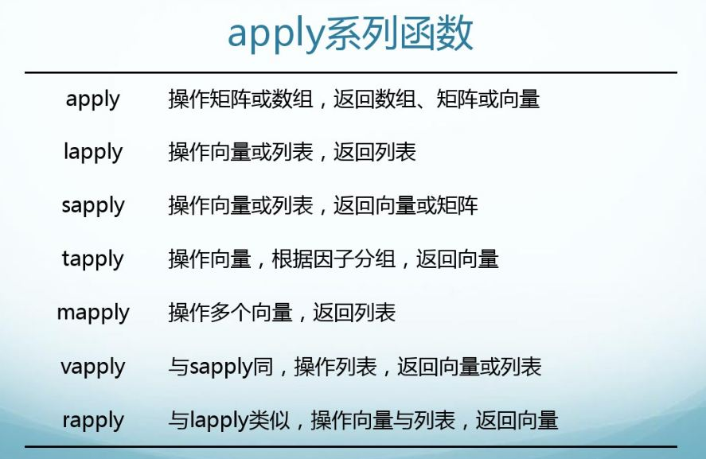

# 1 apply函数（对一个矩阵按行或者按列[就是margin]进行计算）：

## 1.1 usage

| apply | R Documentation |
| --- | --- |

## Apply Functions Over Array Margins

### Description

Returns a vector or array or list of values obtained by applying a function to margins of an array or matrix.

### Usage

```r
apply(X, MARGIN, FUN, ...)
```

### Arguments

| `X` | an array, including a matrix. |
| --- | --- |
| `MARGIN` | a vector giving the subscripts which the function will be applied over. E.g., for a matrix `1` indicates rows, `2` indicates columns, `c(1, 2)` indicates rows and columns. Where `X` has named dimnames… |
| `FUN` | the function to be applied: see ‘Details’. In the case of functions like `+`, `%*%`, etc., the function name must be backquoted or quoted. |
| `…` | optional arguments to `FUN`. |

## 1.2 demo

```r
## Compute row and column sums for a matrix:
x <- cbind(x1 = 3, x2 = c(4:1, 2:5))
dimnames(x)[[1]] <- letters[1:8]
apply(x, 2, mean, trim = .2)
```

```
> x1 x2
>  3  3
```

```r
col.sums <- apply(x, 2, sum)
row.sums <- apply(x, 1, sum)
rbind(cbind(x, Rtot = row.sums), Ctot = c(col.sums, sum(col.sums)))
```

|  | x1 | x2 | Rtot |
| --- | --- | --- | --- |
| a | 3 | 4 | 7 |
| b | 3 | 3 | 6 |
| c | 3 | 2 | 5 |
| d | 3 | 1 | 4 |
| e | 3 | 2 | 5 |
| f | 3 | 3 | 6 |
| g | 3 | 4 | 7 |
| h | 3 | 5 | 8 |
| Ctot | 24 | 24 | 48 |

```r
stopifnot( apply(x, 2, is.vector))

## Sort the columns of a matrix
apply(x, 2, sort)
```

| x1 | x2 |
| --- | --- |
| 3 | 1 |
| 3 | 2 |
| 3 | 2 |
| 3 | 3 |
| 3 | 3 |
| 3 | 4 |
| 3 | 4 |
| 3 | 5 |

```r
## keeping named dimnames
names(dimnames(x)) <- c("row", "col")
x3 <- array(x, dim = c(dim(x),3),
        dimnames = c(dimnames(x), list(C = paste0("cop.",1:3))))
identical(x,  apply( x,  2,  identity))
```

```
> [1] TRUE
```

```r
identical(x3, apply(x3, 2:3, identity))
```

```
> [1] TRUE
```

```r
##- function with extra args:
cave <- function(x, c1, c2) c(mean(x[c1]), mean(x[c2]))
apply(x, 1, cave,  c1 = "x1", c2 = c("x1","x2"))
```

| a | b | c | d | e | f | g | h |
| --- | --- | --- | --- | --- | --- | --- | --- |
| 3.0 | 3 | 3.0 | 3 | 3.0 | 3 | 3.0 | 3 |
| 3.5 | 3 | 2.5 | 2 | 2.5 | 3 | 3.5 | 4 |

```r
ma <- matrix(c(1:4, 1, 6:8), nrow = 2)
ma
```

| 1 | 3 | 1 | 7 |
| --- | --- | --- | --- |
| 2 | 4 | 6 | 8 |

```r
apply(ma, 1, table)  #--> a list of length 2
```

```
> [[1]]
>
> 1 3 7
> 2 1 1
>
> [[2]]
>
> 2 4 6 8
> 1 1 1 1
```

```r
apply(ma, 1, stats::quantile) # 5 x n matrix with rownames
```

| 0% | 1 | 2.0 |
| --- | --- | --- |
| 25% | 1 | 3.5 |
| 50% | 2 | 5.0 |
| 75% | 4 | 6.5 |
| 100% | 7 | 8.0 |

```r
stopifnot(dim(ma) == dim(apply(ma, 1:2, sum)))

## Example with different lengths for each call
z <- array(1:24, dim = 2:4)
zseq <- apply(z, 1:2, function(x) seq_len(max(x)))
zseq         ## a 2 x 3 matrix
```

| 1, 2, 3, 4, 5, 6, 7, 8, 9, 10, 11, 12, 13, 14, 15, 16, 17, 18, 19 | 1, 2, 3, 4, 5, 6, 7, 8, 9, 10, 11, 12, 13, 14, 15, 16, 17, 18, 19, 20, 21 | 1, 2, 3, 4, 5, 6, 7, 8, 9, 10, 11, 12, 13, 14, 15, 16, 17, 18, 19, 20, 21, 22, 23 |
| --- | --- | --- |
| 1, 2, 3, 4, 5, 6, 7, 8, 9, 10, 11, 12, 13, 14, 15, 16, 17, 18, 19, 20 | 1, 2, 3, 4, 5, 6, 7, 8, 9, 10, 11, 12, 13, 14, 15, 16, 17, 18, 19, 20, 21, 22 | 1, 2, 3, 4, 5, 6, 7, 8, 9, 10, 11, 12, 13, 14, 15, 16, 17, 18, 19, 20, 21, 22, 23, 24 |

```r
typeof(zseq) ## list
```

```
> [1] "list"
```

```r
dim(zseq) ## 2 3
```

```
> [1] 2 3
```

```r
zseq[1,]
```

```
> [[1]]
>  [1]  1  2  3  4  5  6  7  8  9 10 11 12 13 14 15 16 17 18 19
>
> [[2]]
>  [1]  1  2  3  4  5  6  7  8  9 10 11 12 13 14 15 16 17 18 19 20 21
>
> [[3]]
>  [1]  1  2  3  4  5  6  7  8  9 10 11 12 13 14 15 16 17 18 19 20 21 22 23
```

```r
apply(z, 3, function(x) seq_len(max(x)))
```

```
> [[1]]
> [1] 1 2 3 4 5 6
>
> [[2]]
>  [1]  1  2  3  4  5  6  7  8  9 10 11 12
>
> [[3]]
>  [1]  1  2  3  4  5  6  7  8  9 10 11 12 13 14 15 16 17 18
>
> [[4]]
>  [1]  1  2  3  4  5  6  7  8  9 10 11 12 13 14 15 16 17 18 19 20 21 22 23
> [24] 24
```

```r
# a list without a dim attribute
```

# 2 函数tapply（进行分组[按照factor变量]统计）：

## 2.1 usage

| tapply | R Documentation |
| --- | --- |

## Apply a Function Over a Ragged Array

### Description

Apply a function to each cell of a ragged array, that is to each (non-empty) group of values given by a unique combination of the levels of certain factors.

### Usage

```r
tapply(X, INDEX, FUN = NULL, ..., simplify = TRUE)
```

### Arguments

| `X` | an atomic object, typically a vector. |
| --- | --- |
| `INDEX` | list of one or more factors, each of same length as `X`. The elements are coerced to factors by `as.factor`. |
| `FUN` | the function to be applied, or `NULL`. In the case of functions like `+`, `%*%`, etc., the function name must be backquoted or quoted. If `FUN` is `NULL`, tapply returns a vector which can be used to … |
| `…` | optional arguments to `FUN`: the Note section. |
| `simplify` | If `FALSE`, `tapply` always returns an array of mode `“list”`. If `TRUE` (the default), then if `FUN` always returns a scalar, `tapply` returns an array with the mode of the scalar. |

## 2.2 demo

```r
require(stats)
groups <- as.factor(rbinom(32, n = 5, prob = 0.4))
tapply(groups, groups, length) #- is almost the same as
```

```
>  8 12 14 15
>  1  1  1  2
```

```r
table(groups)
```

| 8 | 12 | 14 | 15 |
| --- | --- | --- | --- |
| 1 | 1 | 1 | 2 |

```r
## contingency table from data.frame : array with named dimnames
tapply(warpbreaks$breaks, warpbreaks[,-1], sum)
```

|  | L | M | H |
| --- | --- | --- | --- |
| A | 401 | 216 | 221 |
| B | 254 | 259 | 169 |

```r
tapply(warpbreaks$breaks, warpbreaks[, 3, drop = FALSE], sum)
```

```
> tension
>   L   M   H
> 655 475 390
```

```r
n <- 17; fac <- factor(rep(1:3, length = n), levels = 1:5)
table(fac)
```

| 1 | 2 | 3 | 4 | 5 |
| --- | --- | --- | --- | --- |
| 6 | 6 | 5 | 0 | 0 |

```r
tapply(1:n, fac, sum)
```

```
>  1  2  3  4  5
> 51 57 45 NA NA
```

```r
tapply(1:n, fac, sum, simplify = FALSE)
```

```
> $`1`
> [1] 51
>
> $`2`
> [1] 57
>
> $`3`
> [1] 45
>
> $`4`
> NULL
>
> $`5`
> NULL
```

```r
tapply(1:n, fac, range)
```

```
> $`1`
> [1]  1 16
>
> $`2`
> [1]  2 17
>
> $`3`
> [1]  3 15
>
> $`4`
> NULL
>
> $`5`
> NULL
```

```r
tapply(1:n, fac, quantile)
```

```
> $`1`
>    0%   25%   50%   75%  100%
>  1.00  4.75  8.50 12.25 16.00
>
> $`2`
>    0%   25%   50%   75%  100%
>  2.00  5.75  9.50 13.25 17.00
>
> $`3`
>   0%  25%  50%  75% 100%
>    3    6    9   12   15
>
> $`4`
> NULL
>
> $`5`
> NULL
```

```r
## example of ... argument: find quarterly means
tapply(presidents, cycle(presidents), mean, na.rm = TRUE)
```

```
>        1        2        3        4
> 58.44828 56.43333 57.22222 53.07143
```

```r
ind <- list(c(1, 2, 2), c("A", "A", "B"))
table(ind)
```

| ind.1/ind.2 | A | B |
| --- | --- | --- |
| 1 | 1 | 0 |
| 2 | 1 | 1 |

```r
tapply(1:3, ind) #-> the split vector
```

```
> [1] 1 2 4
```

```r
tapply(1:3, ind, sum)
```

| A | B |
| --- | --- |
| 1 | NA |
| 2 | 3 |

```r
## Some assertions (not held by all patch propsals):
nq <- names(quantile(1:5))
stopifnot(
  identical(tapply(1:3, ind), c(1L, 2L, 4L)),
  identical(tapply(1:3, ind, sum),
            matrix(c(1L, 2L, NA, 3L), 2, dimnames = list(c("1", "2"), c("A", "B")))),
  identical(tapply(1:n, fac, quantile)[-1],
            array(list(`2` = structure(c(2, 5.75, 9.5, 13.25, 17), .Names = nq),
                 `3` = structure(c(3, 6, 9, 12, 15), .Names = nq),
                 `4` = NULL, `5` = NULL), dim=4, dimnames=list(as.character(2:5)))))
```

# 3 lapply and sapply

```
lapply的使用格式为：
lapply(X, FUN, ...)
lapply的返回值是和一个和X有相同的长度的list对象，这个list对象中的每个元素是将函数FUN应用到X的每一个元素。其中X为List对象（该list的每个元素都是一个向量），其他类型的对象会被R通过函数as.list()自动转换为list类型。
函数lapply是sapply函数的一个特殊情形，对一些参数的值进行了一些限定，其使用格式为：
sapply(X, FUN,..., simplify = TRUE, USE.NAMES = TRUE)
sapply(*, simplify = FALSE, USE.NAMES = FALSE) 和lapply(*)的返回值是相同的。如果参数simplify=TRUE，则函数sapply的返回值不是一个list，而是一个矩阵；若simplify=FALSE，则函数sapply的返回值仍然是一个list。
```

[figure not shown]

文字的引用网址

## 3.1 usage

| lapply | R Documentation |
| --- | --- |

## Apply a Function over a List or Vector

### Description

`lapply` returns a list of the same length as `X`, each element of which is the result of applying `FUN` to the corresponding element of `X`.

`sapply` is a user-friendly version and wrapper of `lapply` by default returning a vector, matrix or, if `simplify = “array”`, an array if appropriate, by applying `simplify2array()`. `sapply(x, f, simplify = FALSE, USE.NAMES = FALSE)` is the same as `lapply(x, f)`.

`vapply` is similar to `sapply`, but has a pre-specified type of return value, so it can be safer (and sometimes faster) to use.

`replicate` is a wrapper for the common use of `sapply` for repeated evaluation of an expression (which will usually involve random number generation).

`simplify2array()` is the utility called from `sapply()` when `simplify` is not false and is similarly called from `mapply()`.

### Usage

```r
lapply(X, FUN, ...)

sapply(X, FUN, ..., simplify = TRUE, USE.NAMES = TRUE)

vapply(X, FUN, FUN.VALUE, ..., USE.NAMES = TRUE)

replicate(n, expr, simplify = "array")

simplify2array(x, higher = TRUE)
```

### Arguments

| `X` | a vector (atomic or list) or an `expression` object. Other objects (including classed objects) will be coerced by `base::as.list`. |
| --- | --- |
| `FUN` | the function to be applied to each element of `X`: see ‘Details’. In the case of functions like `+`, `%*%`, the function name must be backquoted or quoted. |
| `…` | optional arguments to `FUN`. |
| `simplify` | logical or character string; should the result be simplified to a vector, matrix or higher dimensional array if possible? For `sapply` it must be named and not abbreviated. The default value, `TRUE`, … |
| `USE.NAMES` | logical; if `TRUE` and if `X` is character, use `X` as `names` for the result unless it had names already. Since this argument follows `…` its name cannot be abbreviated. |
| `FUN.VALUE` | a (generalized) vector; a template for the return value from FUN. See ‘Details’. |
| `n` | integer: the number of replications. |
| `expr` | the expression (a language object, usually a call) to evaluate repeatedly. |
| `x` | a list, typically returned from `lapply()`. |
| `higher` | logical; if true, `simplify2array()` will produce a (“higher rank”) array when appropriate, whereas `higher = FALSE` would return a matrix (or vector) only. These two cases correspond to `sapply(*, si… |

## 3.2 demo

```r
require(stats); require(graphics)

x <- list(a = 1:10, beta = exp(-3:3), logic = c(TRUE,FALSE,FALSE,TRUE))
# compute the list mean for each list element
lapply(x, mean)
```

```
> $a
> [1] 5.5
>
> $beta
> [1] 4.535125
>
> $logic
> [1] 0.5
```

```r
# median and quartiles for each list element
lapply(x, quantile, probs = 1:3/4)
```

```
> $a
>  25%  50%  75%
> 3.25 5.50 7.75
>
> $beta
>       25%       50%       75%
> 0.2516074 1.0000000 5.0536690
>
> $logic
> 25% 50% 75%
> 0.0 0.5 1.0
```

```r
sapply(x, quantile)
```

|  | a | beta | logic |
| --- | --- | --- | --- |
| 0% | 1.00 | 0.0497871 | 0.0 |
| 25% | 3.25 | 0.2516074 | 0.0 |
| 50% | 5.50 | 1.0000000 | 0.5 |
| 75% | 7.75 | 5.0536690 | 1.0 |
| 100% | 10.00 | 20.0855369 | 1.0 |

```r
i39 <- sapply(3:9, seq) # list of vectors
sapply(i39, fivenum)
```

| 1.0 | 1.0 | 1 | 1.0 | 1.0 | 1.0 | 1 |
| --- | --- | --- | --- | --- | --- | --- |
| 1.5 | 1.5 | 2 | 2.0 | 2.5 | 2.5 | 3 |
| 2.0 | 2.5 | 3 | 3.5 | 4.0 | 4.5 | 5 |
| 2.5 | 3.5 | 4 | 5.0 | 5.5 | 6.5 | 7 |
| 3.0 | 4.0 | 5 | 6.0 | 7.0 | 8.0 | 9 |

```r
vapply(i39, fivenum,
       c(Min. = 0, "1st Qu." = 0, Median = 0, "3rd Qu." = 0, Max. = 0))
```

| Min. | 1.0 | 1.0 | 1 | 1.0 | 1.0 | 1.0 | 1 |
| --- | --- | --- | --- | --- | --- | --- | --- |
| 1st Qu. | 1.5 | 1.5 | 2 | 2.0 | 2.5 | 2.5 | 3 |
| Median | 2.0 | 2.5 | 3 | 3.5 | 4.0 | 4.5 | 5 |
| 3rd Qu. | 2.5 | 3.5 | 4 | 5.0 | 5.5 | 6.5 | 7 |
| Max. | 3.0 | 4.0 | 5 | 6.0 | 7.0 | 8.0 | 9 |

```r
## sapply(*, "array") -- artificial example
(v <- structure(10*(5:8), names = LETTERS[1:4]))
```

```
>  A  B  C  D
> 50 60 70 80
```

```r
f2 <- function(x, y) outer(rep(x, length.out = 3), y)
(a2 <- sapply(v, f2, y = 2*(1:5), simplify = "array"))
```

```
> , , A
>
>      [,1] [,2] [,3] [,4] [,5]
> [1,]  100  200  300  400  500
> [2,]  100  200  300  400  500
> [3,]  100  200  300  400  500
>
> , , B
>
>      [,1] [,2] [,3] [,4] [,5]
> [1,]  120  240  360  480  600
> [2,]  120  240  360  480  600
> [3,]  120  240  360  480  600
>
> , , C
>
>      [,1] [,2] [,3] [,4] [,5]
> [1,]  140  280  420  560  700
> [2,]  140  280  420  560  700
> [3,]  140  280  420  560  700
>
> , , D
>
>      [,1] [,2] [,3] [,4] [,5]
> [1,]  160  320  480  640  800
> [2,]  160  320  480  640  800
> [3,]  160  320  480  640  800
```

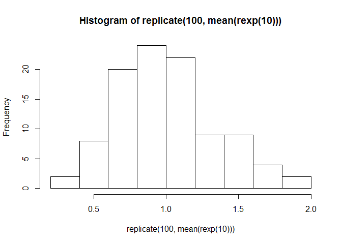

```r
a.2 <- vapply(v, f2, outer(1:3, 1:5), y = 2*(1:5))
stopifnot(dim(a2) == c(3,5,4), all.equal(a2, a.2),
          identical(dimnames(a2), list(NULL,NULL,LETTERS[1:4])))

hist(replicate(100, mean(rexp(10))))
```

```r
## use of replicate() with parameters:
foo <- function(x = 1, y = 2) c(x, y)
# does not work: bar <- function(n, ...) replicate(n, foo(...))
bar <- function(n, x) replicate(n, foo(x = x))
bar(5, x = 3)
```

| 3 | 3 | 3 | 3 | 3 |
| --- | --- | --- | --- | --- |
| 2 | 2 | 2 | 2 | 2 |

# 4 mapply

## 4.1 usage

| mapply | R Documentation |
| --- | --- |

## Apply a Function to Multiple List or Vector Arguments

### Description

`mapply` is a multivariate version of `sapply`. `mapply` applies `FUN` to the first elements of each … argument, the second elements, the third elements, and so on. Arguments are recycled if necessary.

### Usage

```r
mapply(FUN, ..., MoreArgs = NULL, SIMPLIFY = TRUE,
       USE.NAMES = TRUE)
```

### Arguments

| `FUN` | function to apply, found via `match.fun`. |
| --- | --- |
| `…` | arguments to vectorize over (vectors or lists of strictly positive length, or all of zero length). See also ‘Details’. |
| `MoreArgs` | a list of other arguments to `FUN`. |
| `SIMPLIFY` | logical or character string; attempt to reduce the result to a vector, matrix or higher dimensional array; see the `simplify` argument of `sapply`. |
| `USE.NAMES` | logical; use names if the first … argument has names, or if it is a character vector, use that character vector as the names. |

## 4.2 demo

```r
mapply(rep, 1:4, 4:1)
```

```
> [[1]]
> [1] 1 1 1 1
>
> [[2]]
> [1] 2 2 2
>
> [[3]]
> [1] 3 3
>
> [[4]]
> [1] 4
```

```r
#直接使用函数rep的结果：
rep(1:4,1:4)
```

```
>  [1] 1 2 2 3 3 3 4 4 4 4
```

```r
mapply(rep, times = 1:4, x = 4:1)
```

```
> [[1]]
> [1] 4
>
> [[2]]
> [1] 3 3
>
> [[3]]
> [1] 2 2 2
>
> [[4]]
> [1] 1 1 1 1
```

```r
mapply(rep, times = 1:4, MoreArgs = list(x = 42))
```

```
> [[1]]
> [1] 42
>
> [[2]]
> [1] 42 42
>
> [[3]]
> [1] 42 42 42
>
> [[4]]
> [1] 42 42 42 42
```

```r
mapply(function(x, y) seq_len(x) + y,
       c(a =  1, b = 2, c = 3),  # names from first
       c(A = 10, B = 0, C = -10))
```

```
> $a
> [1] 11
>
> $b
> [1] 1 2
>
> $c
> [1] -9 -8 -7
```

```r
word <- function(C, k) paste(rep.int(C, k), collapse = "")
utils::str(mapply(word, LETTERS[1:6], 6:1, SIMPLIFY = FALSE))
```

```
> List of 6
>  $ A: chr "AAAAAA"
>  $ B: chr "BBBBB"
>  $ C: chr "CCCC"
>  $ D: chr "DDD"
>  $ E: chr "EE"
>  $ F: chr "F"
```